# Caedon paper

Caedon Ott

2022-12-14

To start out my analysis, I had to figure out how I was going to sample from such a massive data set. I used the following function to sample from a selected indicator with parameters `m` and `n`:

```r
f1 <- function(data, m,n){

  bootstrap_data <- list()
  for(i in 1:m){
    temp_sample_ind <- sample(1:length(data), n,replace=TRUE)
    bootstrap_data[[i]] <- data[temp_sample_ind]
  }
  return(bootstrap_data)
}
```

I used the equation:

$g(u) = \hat{F}^{-1}(\phi(z_0 + \frac{z_0 + z_u}{1-a(z_0+z_u)}))$

Lower bound = $g(\alpha/2)$, Upper bound = $g(1-\alpha/2)$ $\phi$ is the standard normal cdf $\hat{F}$ is the bootstrap cdf $z_0 = \phi^{-1}F(\hat{\theta})$, quantile of mean of theta_boot <= theta_hat $z_u = \phi^{-1}(u)$, quantiles of our desired bounds

$\hat{a} = \frac{1}{6}\frac{\sum_{i=1}^n I_i^3}{(\sum_{i=1}^n I_i^2)^{3/2}}$

$I_i = (n-1)(\hat{\theta}-\hat{\theta}_{-i})$ finite sample jacknife approx.

I implemented $g(u)$ with this code:

```r
bca_CI <- function(theta_boot,theta_hat,m){

  alpha <- 0.05
  u <- c(alpha/2, 1-alpha/2)
  z0 <- qnorm(mean(theta_boot <= theta_hat))
  zu <- qnorm(u)
  a <- 0
  #because the sample size of our data set is so large, the computation
  #is too intensive for rstudio to conduct. With such a large data set a should
  #be close to zero anyways, so I elected to choose zero.

  u_adjusted <- pnorm(z0 + (z0+zu)/(1-a*(z0+zu)))
  #u_adjusted <- pnorm(z0 + (z0+zu)/(1-a_approx*(z0+zu)))
  conf_int <- quantile(theta_boot,u_adjusted)
  return(conf_int)

}
```

Originally, I did not have `a` set to zero. I used this function to approximate `a`:

```r
a_est <- function(data,theta_hat){
  n <- length(data)
  I <- rep(NA, n)
for(i in 1:n){
   #Remove ith data point
   xnew <- data[-i]
   #Estimate theta
   theta_jack <- mean(xnew)
   I[i] <- (n-1)*(theta_hat - theta_jack)
}
#Estimate a
  a_hat <- (sum(I^3)/sum(I^2)^1.5)/6
  return(a_hat)
}
```

Now I was ready to perform BCa confidence intervals! I threw in the data of my selected indicator, and clicked run.

Here is where I started running into problems. My computer ran for about 10 minutes before I eventually halted the program. Why was this taking so long?

To first check and see if I was doing something wrong, I used the boot.ci package to compute a BCa confidence interval. However, this also would run and begin taxing the memory allocation. I checked the other confidence intervals and noticed that they would compute almost immediately. There was something about the BCa computation that was computationally intensive.

After staring at my code and equation for two days, I finally made a breakthrough. `a` has to iterate through every single observation, take (n-1) * (mean of the dataset - mean of the dataset with one less observation), and plug it into $I_n$. I realized that this computation was happening 253,680 times (the length of the number of observations per column in our data set). This was a massive calculation. I read more into what the acceleration constant actually meant, and realized that it was adjusting for skew using the infinitesimal jackknife method, which reasonably approximates `a` with smaller sample sizes. With a very high `n`, the central limit theorem kicks in, and each indicator is approximately normally distributed. Thus, with a normal distribution, the skew approaches zero as `n` -> infinity. Therefore, I made the choice to set `a` as zero, which effectively changes my Bias corrected and accelerated confidence intervals to Bias corrected confidence intervals.

With `a` now set to zero, I could start computing confidence intervals. I decided to create a master function that sampled from a selected indicator for no diabetes, pre diabetes, and diabetes, with a vector of all desired boot strap replications and sample sizes. I also had to include the overall mean for each indicator so it could be used in the BCa function call.

```r
bca_compile <- function(data0,data1,data2,theta_hat1,theta_hat2,theta_hat3,m,n){
  data.stats = setNames(data.frame(matrix(ncol = 12, nrow = length(m)*length(n))),
                 c("mean1", "sd1","ci_1_lower","ci_1_upper","mean2", "sd2","ci_2_lower","ci_2_upper","mean3", "sd3","ci_3_lower","ci_3_upper"))
  row.names(data.stats) <- c("m5,n10","m5,n25","m5,n75","m5,n125","m5,n250","m10,n10","m10,n25","m10,n75","m10,n125","m10,n250","m15,n10","m15,n25","m15,n75","m15,n125","m15,n250","m30,n10","m30,n25","m30,n75","m30,n125","m30,n250","m50,n10","m50,n25","m50,n75","m50,n125","m50,n250")
  counter=1
  bca_CI_means <- data.frame(matrix(ncol=3,nrow=m[5]))
  for(r in 1:length(m)){
    for(c in 1:length(n)){
      b0 <- f1(data0,m[r],n[c])
      b0_mean <- b_means(b0,m[r])
      b0_se <- b_sds(b0,m[r])

      b1 <- f1(data1,m[r],n[c])
      b1_mean <- b_means(b1,m[r])
      b1_se <- b_sds(b1,m[r])

      b2<- f1(data2,m[r],n[c])
      b2_mean <- b_means(b2,m[r])
      b2_se <- b_sds(b2,m[r])

      # b_mean_diff <- rep(NA,m[r])
      # b_se_diff <- rep(NA,m[r])
      # for(i in 1:m[r]){
      #   b_mean_diff[i] <- b0_mean[i]-b1_mean[i]
      #   b_se_diff[i] <- b0_se[i]-b1_se[i]
      # }
      # b_theta_hat_diff <- theta_hat1-theta_hat2
      #
      #
      #
      # b_ci_diff <- bca_CI(b_mean_diff,b_theta_hat_diff,m[r])
      b0_ci <- bca_CI(b0_mean,theta_hat1,m[r])
      b1_ci <- bca_CI(b1_mean,theta_hat2,m[r])
      b2_ci <- bca_CI(b2_mean,theta_hat3,m[r])

      data.stats[counter,] <- c(mean(b0_mean),mean(b0_se),b0_ci[1],b0_ci[2],mean(b1_mean),mean(b1_se),b1_ci[1],b1_ci[2],mean(b2_mean),mean(b2_se),b2_ci[1],b2_ci[2])
      counter <- counter + 1
      if(m[r] == 50 & n[c] == 250){
        bca_CI_means[,1] <- b0_mean
        bca_CI_means[,2] <- b1_mean
        bca_CI_means[,3] <- b2_mean

      }
    }
  }


  return(list(data.stats,bca_CI_means))

}
```

This function returns a list of two data frames. The first data frame is a master data frame which has the mean, standard error, and bounds for the BCa confidence interval for no diabetes, pre-diabetes, and diabetes of a selected indicator, for all `m` and `n`. The second data frame is a list of the means of each bootstrapped sample for `m` = 50 and `n` = 250, which I used to plot the histograms.

Now was time to plot my results and showcase the relationships. I started by creating master functions for each variable, as well as creating data frames with labels so that the data could be plotted and readable.

```r
m_vec <- c(5,10,15,30,50)
n_vec <- c(10,25,75,125,250)

nodibindic <- rep("No Diabetes",50)
predibindic <- rep("Pre Diabetes",50)
dibindic <- rep("Diabetes",50)
indic <- c(nodibindic,predibindic,dibindic)



a <- bca_compile(nodib$HighBP,predib$HighBP,dib$HighBP,mean(nodib$HighBP),mean(predib$HighBP),mean(dib$HighBP),m_vec,n_vec)
a1 <- a[[1]]
a2 <- a[[2]]
highBP <- c(a2[,1],a2[,2],a2[,3])
#a3 <- cbind(a3,indic)
a3 <- data.frame(highBP,group=indic)

b <- bca_compile(nodib$HighChol,predib$HighChol,dib$HighChol,mean(nodib$HighChol),mean(predib$HighChol),mean(dib$HighChol),m_vec,n_vec)
b1 <- b[[1]]
b2 <- b[[2]]
highChol <- c(b2[,1],b2[,2],b2[,3])
b3 <- data.frame(highChol,group = indic)

c <- bca_compile(nodib$BMI,predib$BMI,dib$BMI,mean(nodib$BMI),mean(predib$BMI),mean(dib$BMI),m_vec,n_vec)
c1 <- c[[1]]
c2 <- c[[2]]
BMI <- c(c2[,1],c2[,2],c2[,3])
c3 <- data.frame(BMI,group=indic)

d <- bca_compile(nodib$AnyHealthcare,predib$AnyHealthcare,dib$AnyHealthcare,mean(nodib$AnyHealthcare),mean(predib$AnyHealthcare),mean(dib$AnyHealthcare),m_vec,n_vec)
d1 <- d[[1]]
d2 <- d[[2]]
AnyHealthcare <- c(d2[,1],d2[,2],d2[,3])
d3 <- data.frame(AnyHealthcare,group=indic)

e <- bca_compile(nodib$GenHlth,predib$GenHlth,dib$GenHlth,mean(nodib$GenHlth),mean(predib$GenHlth),mean(dib$GenHlth),m_vec,n_vec)
e1 <- e[[1]]
e2 <- e[[2]]
GenHlth <- c(e2[,1],e2[,2],e2[,3])
e3 <- data.frame(GenHlth,group=indic)

f <- bca_compile(nodib$Income,predib$Income,dib$Income,mean(nodib$Income),mean(predib$Income),mean(dib$Income),m_vec,n_vec)
f1 <- f[[1]]
f2 <- f[[2]]
Income <- c(f2[,1],f2[,2],f2[,3])
f3 <- data.frame(Income,group=indic)
```

Next, I created a table function that would neatly display the mean, standard error, and the bounds for a selected bootstrap replication and sample size. I decided to compare the smallest and largest bootstrap samples to really showcase the power of boostrapping. The table functions I created are displayed below.

```r
make_table <- function(data){
  t = setNames(data.frame(matrix(ncol = 4, nrow = 3)), c("Mean", "SD","CI_Low","CI_High"))
  row.names(t) <- c("No Diabetes","Pre Diabetes","Diabetes")
  t[1,1] = data[25,1]
  t[2,1] = data[25,5]
  t[3,1] = data[25,9]

  t[1,2] = data[25,2]
  t[2,2] = data[25,6]
  t[3,2] = data[25,10]

  t[1,3] = data[25,3]
  t[2,3] = data[25,7]
  t[3,3] = data[25,11]

  t[1,4] = data[25,4]
  t[2,4] = data[25,8]
  t[3,4] = data[25,12]

  return(t)
}
make_table2 <- function(data){
  t = setNames(data.frame(matrix(ncol = 4, nrow = 3)), c("Mean", "SD","CI_Low","CI_High"))
  row.names(t) <- c("No Diabetes","Pre Diabetes","Diabetes")
  t[1,1] = data[1,1]
  t[2,1] = data[1,5]
  t[3,1] = data[1,9]

  t[1,2] = data[1,2]
  t[2,2] = data[1,6]
  t[3,2] = data[1,10]

  t[1,3] = data[1,3]
  t[2,3] = data[1,7]
  t[3,3] = data[1,11]

  t[1,4] = data[1,4]
  t[2,4] = data[1,8]
  t[3,4] = data[1,12]

  return(t)
}
```

Now, it’s time to show off the hard work! I formatted each slide to display the two tables and a histogram of the bootstrapped means. Over the top of each histogram is the BCa confidence interval for `m` = 50 and `n` = 250, and directly below it the BCa confidence interval for `m` = 5 and `n` = 10.

## BCa High Blood Pressure

High Blood Pressure m=50 n=250

|  | Mean | SD | CI_Low | CI_High |
| --- | --- | --- | --- | --- |
| No Diabetes | 0.371 | 0.483 | 0.320 | 0.430 |
| Pre Diabetes | 0.638 | 0.480 | 0.532 | 0.700 |
| Diabetes | 0.761 | 0.426 | 0.693 | 0.798 |

High Blood Pressure m=5 n=10

|  | Mean | SD | CI_Low | CI_High |
| --- | --- | --- | --- | --- |
| No Diabetes | 0.38 | 0.500 | 0.2 | 0.400 |
| Pre Diabetes | 0.66 | 0.491 | 0.6 | 0.797 |
| Diabetes | 0.74 | 0.438 | 0.6 | 0.871 |

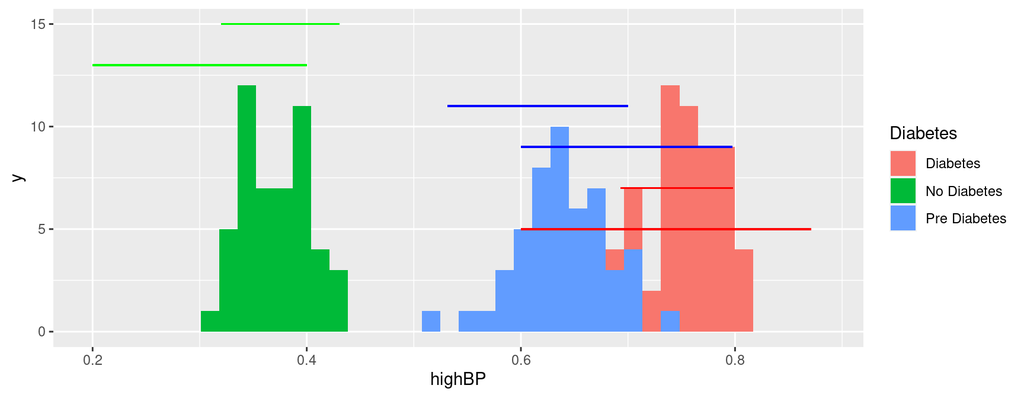

## BCa High Cholesterol

High Cholesterol m=50 n=250

|  | Mean | SD | CI_Low | CI_High |
| --- | --- | --- | --- | --- |
| No Diabetes | 0.378 | 0.485 | 0.310 | 0.436 |
| Pre Diabetes | 0.626 | 0.484 | 0.558 | 0.668 |
| Diabetes | 0.671 | 0.470 | 0.620 | 0.705 |

High Cholesterol m=5 n=10

|  | Mean | SD | CI_Low | CI_High |
| --- | --- | --- | --- | --- |
| No Diabetes | 0.44 | 0.512 | 0.300 | 0.444 |
| Pre Diabetes | 0.64 | 0.503 | 0.600 | 0.700 |
| Diabetes | 0.56 | 0.512 | 0.556 | 0.700 |

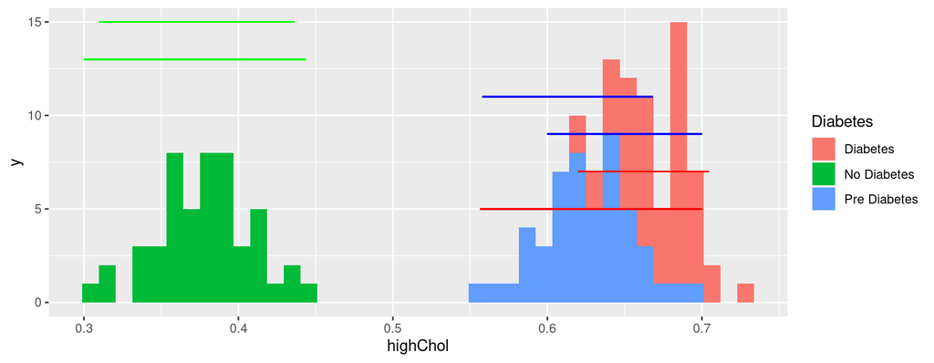

## BCa BMI

BMI m=50 n=250

|  | Mean | SD | CI_Low | CI_High |
| --- | --- | --- | --- | --- |
| No Diabetes | 27.670 | 6.096 | 27.141 | 28.568 |
| Pre Diabetes | 30.754 | 6.848 | 29.911 | 31.514 |
| Diabetes | 32.007 | 7.413 | 31.105 | 32.712 |

BMI m=5 n=10

|  | Mean | SD | CI_Low | CI_High |
| --- | --- | --- | --- | --- |
| No Diabetes | 28.98 | 5.76 | 26.716 | 30.737 |
| Pre Diabetes | 31.14 | 7.82 | 29.430 | 32.042 |
| Diabetes | 31.24 | 7.65 | 30.895 | 32.500 |

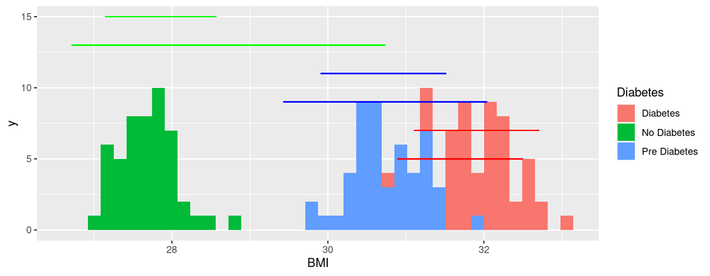

## BCa Any Healthcare

Any Healthcare m=50 n=250

|  | Mean | SD | CI_Low | CI_High |
| --- | --- | --- | --- | --- |
| No Diabetes | 0.949 | 0.217 | 0.918 | 0.976 |
| Pre Diabetes | 0.941 | 0.235 | 0.932 | 0.968 |
| Diabetes | 0.959 | 0.197 | 0.948 | 0.980 |

Any Healthcare m=5 n=10

|  | Mean | SD | CI_Low | CI_High |
| --- | --- | --- | --- | --- |
| No Diabetes | 0.94 | 0.148 | 0.803 | 1 |
| Pre Diabetes | 0.94 | 0.148 | 0.803 | 1 |
| Diabetes | 0.92 | 0.211 | 0.829 | 1 |

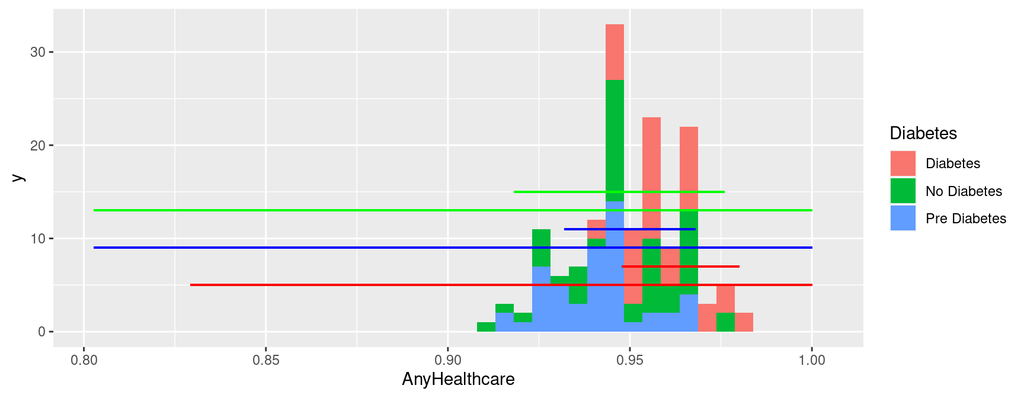

## BCa General Health

General Health m=50 n=250

|  | Mean | SD | CI_Low | CI_High |
| --- | --- | --- | --- | --- |
| No Diabetes | 2.374 | 1.018 | 2.265 | 2.455 |
| Pre Diabetes | 2.971 | 1.028 | 2.841 | 3.108 |
| Diabetes | 3.311 | 1.011 | 3.169 | 3.363 |

General Health m=5 n=10

[output not shown]

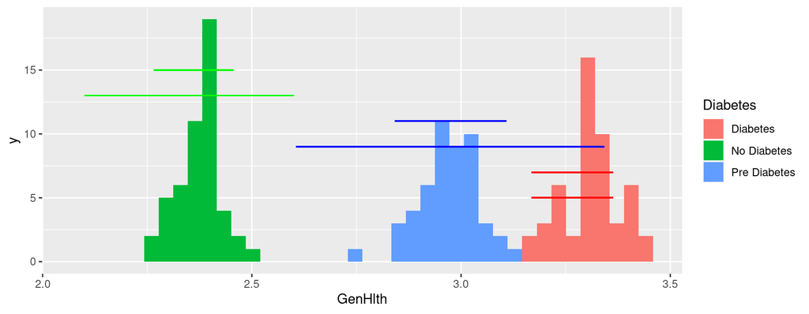

## BCa Income

Income m=50 n=250

[output not shown]

Income m=5 n=10

[output not shown]

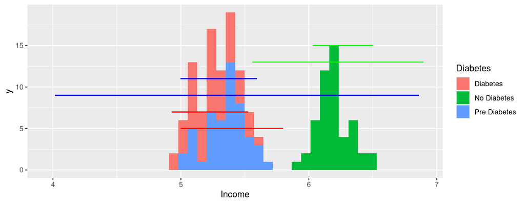